# Biostat 203B Homework 5

Due March 20nd, 2025 @ 11:59PM

Author

Luke Hodges 906182810

## Loading in the necessary libraries and data file

```r
# Load required libraries
library(tidyverse)
library(tidymodels)
library(glmnet)
library(GGally)
library(ranger)
library(gtsummary)
library(stacks)
library(xgboost)
library(vip)
# Load the MIMIC-IV dataset

mimic_icu_cohort <- readRDS("../homework4/mimiciv_shiny/mimic_icu_cohort.rds")

mimic_icu_cohort <- mimic_icu_cohort |>
  arrange(subject_id, hadm_id, stay_id)

mimic_icu_cohort <- mimic_icu_cohort |>
  mutate(los_long = factor(los >= 2, levels = c(FALSE, TRUE),
                           labels = c("FALSE", "TRUE")))

mimic_icu_cohort$los_long <- as.factor(mimic_icu_cohort$los_long)
```

## Logistic Regression

**Data preprocessing and feature engineering.**

```r
#Remove ID Columns and then Select the Predictors
icu_data <- mimic_icu_cohort %>%
  select(subject_id, hadm_id, stay_id, los_long, first_careunit, gender,
         age_intime, marital_status, race, Heart_Rate, DiaBP, SysBP,
         Respiratory_Rate, Temp, Creatinine, Potassium, Chloride, Bicarbonate,
         Hematocrit, WBC, Sodium, Glucose)

icu_data <- icu_data %>%
  arrange(subject_id, hadm_id, stay_id)
```

```r
##We need to make sure that los_long is a factor as we got this as an error
icu_data$los_long <- as.factor(icu_data$los_long)

##Now we need to remove all the NA values
icu_data <- icu_data %>%
  drop_na(first_careunit, gender, age_intime, marital_status, race, Heart_Rate,
          DiaBP, SysBP, Respiratory_Rate, Temp, Creatinine, Potassium,
          Chloride, Bicarbonate, Hematocrit, WBC, Sodium, Glucose)

##We can check to see if there are any NAs here
colSums(is.na(icu_data))
```

```
      subject_id          hadm_id          stay_id         los_long
               0                0                0                0
  first_careunit           gender       age_intime   marital_status
               0                0                0                0
            race       Heart_Rate            DiaBP            SysBP
               0                0                0                0
Respiratory_Rate             Temp       Creatinine        Potassium
               0                0                0                0
        Chloride      Bicarbonate       Hematocrit              WBC
               0                0                0                0
          Sodium          Glucose
               0                0
```

**Partition data into 50% training set and 50% test set. Stratify partitioning according to los_long. For grading purpose, sort the data by subject_id, hadm_id, and stay_id and use the seed 203 for the initial data split.**

```r
set.seed(203)

# Stratified split by los_long
icu_split <- initial_split(
  icu_data,
  strata = los_long,
  prop = 0.5
)

icu_train <- training(icu_split)
icu_test <- testing(icu_split)
```

```r
head(icu_train)
```

```
# A tibble: 6 × 22
  subject_id  hadm_id  stay_id los_long first_careunit         gender age_intime
       <int>    <int>    <int> <fct>    <chr>                  <chr>       <int>
1   10000980 26913865 39765666 FALSE    Medical Intensive Car… F              76
2   10002155 20345487 32358465 FALSE    Medical Intensive Car… F              83
3   10003019 22774359 30676350 FALSE    Medical/Surgical Inte… M              73
4   10003502 29011269 35796366 FALSE    Coronary Care Unit (C… F              94
5   10004457 23251352 31494479 FALSE    Cardiac Vascular Inte… M              66
6   10005348 25239799 34629895 FALSE    Cardiac Vascular Inte… M              78
# ℹ 15 more variables: marital_status <chr>, race <chr>, Heart_Rate <dbl>,
#   DiaBP <dbl>, SysBP <dbl>, Respiratory_Rate <dbl>, Temp <dbl>,
#   Creatinine <dbl>, Potassium <dbl>, Chloride <dbl>, Bicarbonate <dbl>,
#   Hematocrit <dbl>, WBC <dbl>, Sodium <dbl>, Glucose <dbl>
```

```r
dim(icu_train)
```

```
[1] 37569    22
```

```r
head(icu_test)
```

```
# A tibble: 6 × 22
  subject_id  hadm_id  stay_id los_long first_careunit         gender age_intime
       <int>    <int>    <int> <fct>    <chr>                  <chr>       <int>
1   10000032 29079034 39553978 FALSE    Medical Intensive Car… F              52
2   10001217 24597018 37067082 FALSE    Surgical Intensive Ca… F              55
3   10001217 27703517 34592300 FALSE    Surgical Intensive Ca… F              55
4   10001843 26133978 39698942 FALSE    Medical/Surgical Inte… M              76
5   10001884 26184834 37510196 TRUE     Medical Intensive Car… F              77
6   10002013 23581541 39060235 FALSE    Cardiac Vascular Inte… F              57
# ℹ 15 more variables: marital_status <chr>, race <chr>, Heart_Rate <dbl>,
#   DiaBP <dbl>, SysBP <dbl>, Respiratory_Rate <dbl>, Temp <dbl>,
#   Creatinine <dbl>, Potassium <dbl>, Chloride <dbl>, Bicarbonate <dbl>,
#   Hematocrit <dbl>, WBC <dbl>, Sodium <dbl>, Glucose <dbl>
```

```r
dim(icu_test)
```

```
[1] 37571    22
```

```r
##Now, let us make the logit_recipe for the logistic regression model

logit_recipe <- recipe(
  los_long ~ first_careunit + gender + age_intime + marital_status + race +
    Heart_Rate + DiaBP + SysBP + Respiratory_Rate + Temp +
    Creatinine + Potassium + Chloride + Bicarbonate + Hematocrit +
    WBC + Sodium + Glucose,
  data = icu_train
) %>%
  step_impute_median(all_numeric_predictors()) %>%
  step_impute_mode(all_nominal_predictors()) %>%
  step_novel(all_nominal_predictors()) %>%
  step_dummy(all_nominal_predictors()) %>%
  step_zv(all_predictors()) %>%
  step_normalize(all_numeric_predictors())

logit_recipe
```

```
── Recipe ──────────────────────────────────────────────────────────────────────
```

```
── Inputs
```

```
Number of variables by role
```

```
outcome:    1
predictor: 18
```

```
── Operations
```

```
• Median imputation for: all_numeric_predictors()
```

```
• Mode imputation for: all_nominal_predictors()
```

```
• Novel factor level assignment for: all_nominal_predictors()
```

```
• Dummy variables from: all_nominal_predictors()
```

```
• Zero variance filter on: all_predictors()
```

```
• Centering and scaling for: all_numeric_predictors()
```

**Train and tune the models using the training set.**

```r
logit_mod <- logistic_reg(
  penalty = tune(),
  mixture = tune()
) %>%
  set_engine("glmnet", standardize = TRUE) %>%
  set_mode("classification") %>%
  print()
```

```
Logistic Regression Model Specification (classification)

Main Arguments:
  penalty = tune()
  mixture = tune()

Engine-Specific Arguments:
  standardize = TRUE

Computational engine: glmnet
```

```r
logit_mod
```

```
Logistic Regression Model Specification (classification)

Main Arguments:
  penalty = tune()
  mixture = tune()

Engine-Specific Arguments:
  standardize = TRUE

Computational engine: glmnet
```

```r
logit_wf <- workflow() %>%
  add_recipe(logit_recipe) %>%
  add_model(logit_mod) %>%
  print()
```

```
══ Workflow ════════════════════════════════════════════════════════════════════
Preprocessor: Recipe
Model: logistic_reg()

── Preprocessor ────────────────────────────────────────────────────────────────
6 Recipe Steps

• step_impute_median()
• step_impute_mode()
• step_novel()
• step_dummy()
• step_zv()
• step_normalize()

── Model ───────────────────────────────────────────────────────────────────────
Logistic Regression Model Specification (classification)

Main Arguments:
  penalty = tune()
  mixture = tune()

Engine-Specific Arguments:
  standardize = TRUE

Computational engine: glmnet
```

```r
logit_wf
```

```
══ Workflow ════════════════════════════════════════════════════════════════════
Preprocessor: Recipe
Model: logistic_reg()

── Preprocessor ────────────────────────────────────────────────────────────────
6 Recipe Steps

• step_impute_median()
• step_impute_mode()
• step_novel()
• step_dummy()
• step_zv()
• step_normalize()

── Model ───────────────────────────────────────────────────────────────────────
Logistic Regression Model Specification (classification)

Main Arguments:
  penalty = tune()
  mixture = tune()

Engine-Specific Arguments:
  standardize = TRUE

Computational engine: glmnet
```

```r
param_grid <- grid_regular(
  penalty(range = c(-6, 3)),   # log10 scale
  mixture(),
  levels = c(100, 5)
) %>%
  print()
```

```
# A tibble: 500 × 2
      penalty mixture
        <dbl>   <dbl>
 1 0.000001         0
 2 0.00000123       0
 3 0.00000152       0
 4 0.00000187       0
 5 0.00000231       0
 6 0.00000285       0
 7 0.00000351       0
 8 0.00000433       0
 9 0.00000534       0
10 0.00000658       0
# ℹ 490 more rows
```

```r
#We are going to use a v = 3 since my laptop takes a while to load v = 3. We need to make sure this stays consistent for the next few models

set.seed(203)
cv_folds <- vfold_cv(icu_train, v = 3)
```

```r
(logit_tune <- tune_grid(
  object = logit_wf,
  resamples = cv_folds,
  grid = param_grid,
  metrics = metric_set(roc_auc, accuracy),
  control = control_stack_grid()
)) |>
  system.time()
```

```
ℹ The workflow being saved contains a recipe, which is 5.23 Mb in ℹ memory. If
this was not intentional, please set the control setting ℹ `save_workflow =
FALSE`.
```

```
   user  system elapsed
 64.342   9.197  74.823
```

```r
logit_tune
```

```
# Tuning results
# 3-fold cross-validation
# A tibble: 3 × 5
  splits                id    .metrics             .notes           .predictions
  <list>                <chr> <list>               <list>           <list>
1 <split [25046/12523]> Fold1 <tibble [1,000 × 6]> <tibble [0 × 4]> <tibble>
2 <split [25046/12523]> Fold2 <tibble [1,000 × 6]> <tibble [0 × 4]> <tibble>
3 <split [25046/12523]> Fold3 <tibble [1,000 × 6]> <tibble [0 × 4]> <tibble>
```

```r
logit_tune_roc <- logit_tune |>
  collect_metrics() |>
  filter(.metric == "roc_auc")

logit_tune_roc
```

```
# A tibble: 500 × 8
      penalty mixture .metric .estimator  mean     n std_err .config
        <dbl>   <dbl> <chr>   <chr>      <dbl> <int>   <dbl> <chr>
 1 0.000001         0 roc_auc binary     0.609     3 0.00192 Preprocessor1_Mode…
 2 0.00000123       0 roc_auc binary     0.609     3 0.00192 Preprocessor1_Mode…
 3 0.00000152       0 roc_auc binary     0.609     3 0.00192 Preprocessor1_Mode…
 4 0.00000187       0 roc_auc binary     0.609     3 0.00192 Preprocessor1_Mode…
 5 0.00000231       0 roc_auc binary     0.609     3 0.00192 Preprocessor1_Mode…
 6 0.00000285       0 roc_auc binary     0.609     3 0.00192 Preprocessor1_Mode…
 7 0.00000351       0 roc_auc binary     0.609     3 0.00192 Preprocessor1_Mode…
 8 0.00000433       0 roc_auc binary     0.609     3 0.00192 Preprocessor1_Mode…
 9 0.00000534       0 roc_auc binary     0.609     3 0.00192 Preprocessor1_Mode…
10 0.00000658       0 roc_auc binary     0.609     3 0.00192 Preprocessor1_Mode…
# ℹ 490 more rows
```

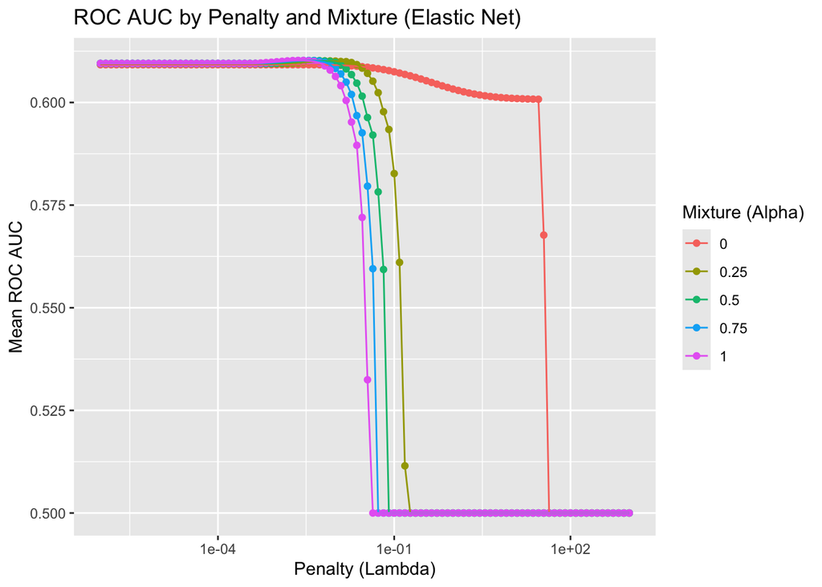

```r
logit_tune_roc |>
  ggplot(aes(x = penalty, y = mean, color = factor(mixture))) +
  geom_point() +
  geom_line() +
  labs(
    title = "ROC AUC by Penalty and Mixture (Elastic Net)",
    x = "Penalty (Lambda)",
    y = "Mean ROC AUC",
    color = "Mixture (Alpha)"
  ) +
  scale_x_log10()
```

**Compare model classification performance on the test set. Report both the area under ROC curve and accuracy for each machine learning algorithm and the model stacking. Interpret the results. What are the most important features in predicting long ICU stays?**

```r
show_best(logit_tune, metric = "roc_auc")
```

```
# A tibble: 5 × 8
  penalty mixture .metric .estimator  mean     n std_err .config
    <dbl>   <dbl> <chr>   <chr>      <dbl> <int>   <dbl> <chr>
1 0.00285    1    roc_auc binary     0.610     3 0.00216 Preprocessor1_Model439
2 0.00231    1    roc_auc binary     0.610     3 0.00213 Preprocessor1_Model438
3 0.00351    0.75 roc_auc binary     0.610     3 0.00215 Preprocessor1_Model340
4 0.00285    0.75 roc_auc binary     0.610     3 0.00210 Preprocessor1_Model339
5 0.00433    0.5  roc_auc binary     0.610     3 0.00210 Preprocessor1_Model241
```

```r
best_logit <- select_best(logit_tune, metric = "roc_auc")
best_logit
```

```
# A tibble: 1 × 3
  penalty mixture .config
    <dbl>   <dbl> <chr>
1 0.00285       1 Preprocessor1_Model439
```

```r
final_logit_wf <- finalize_workflow(
  logit_wf,
  best_logit
)

final_logit_fit <- last_fit(
  final_logit_wf,
  split = icu_split
)

# Collect metrics on the test set
collect_metrics(final_logit_fit)
```

```
# A tibble: 3 × 4
  .metric     .estimator .estimate .config
  <chr>       <chr>          <dbl> <chr>
1 accuracy    binary         0.579 Preprocessor1_Model1
2 roc_auc     binary         0.607 Preprocessor1_Model1
3 brier_class binary         0.241 Preprocessor1_Model1
```

```r
predictions <- collect_predictions(final_logit_fit)

predictions %>%
  select(los_long, .pred_TRUE, .pred_class) %>%
  head(10)
```

```
# A tibble: 10 × 3
   los_long .pred_TRUE .pred_class
   <fct>         <dbl> <fct>
 1 FALSE         0.449 FALSE
 2 FALSE         0.419 FALSE
 3 FALSE         0.385 FALSE
 4 FALSE         0.514 TRUE
 5 TRUE          0.314 FALSE
 6 FALSE         0.472 FALSE
 7 TRUE          0.494 FALSE
 8 TRUE          0.504 TRUE
 9 TRUE          0.425 FALSE
10 FALSE         0.396 FALSE
```

```r
conf_mat(predictions, truth = los_long, estimate = .pred_class)
```

```
          Truth
Prediction FALSE  TRUE
     FALSE 12655  9197
     TRUE   6608  9111
```

```r
final_model <- extract_fit_parsnip(final_logit_fit$.workflow[[1]])
tidy(final_model) %>%
  arrange(desc(estimate)) %>%
  print(n = Inf)
```

```
# A tibble: 66 × 3
   term                                                         estimate penalty
   <chr>                                                           <dbl>   <dbl>
 1 first_careunit_Neuro.Intermediate                             1.54e-1 0.00285
 2 Heart_Rate                                                    1.44e-1 0.00285
 3 Respiratory_Rate                                              1.22e-1 0.00285
 4 age_intime                                                    1.01e-1 0.00285
 5 WBC                                                           6.44e-2 0.00285
 6 first_careunit_Surgery.Vascular.Intermediate                  6.39e-2 0.00285
 7 Creatinine                                                    4.52e-2 0.00285
 8 gender_M                                                      3.43e-2 0.00285
 9 race_UNKNOWN                                                  3.04e-2 0.00285
10 Bicarbonate                                                   2.35e-2 0.00285
11 race_UNABLE.TO.OBTAIN                                         2.20e-2 0.00285
12 first_careunit_Neuro.Stepdown                                 1.84e-2 0.00285
```

[output cut: 54 more lines]

```r
levels(predictions$los_long)
```

```
[1] "FALSE" "TRUE"
```

```r
roc_auc(predictions, truth = los_long, .pred_TRUE, event_level = "second")
```

```
# A tibble: 1 × 3
  .metric .estimator .estimate
  <chr>   <chr>          <dbl>
1 roc_auc binary         0.607
```

**The Accuracy is 0.579; the ROC AUC is 0.607; and the Brier score is 0.241. Regrading accuracy, this means that 57.9% of the time, the model correctly predicts whether or not a patient has a long or short ICU stay based on the features examined. This means that this is better than just randomly guessing, which would give more of a 50-50 split.**

**The ROC AUC indicates that the model is able to distinguish ICU stays between long and short in a modest way.**

**The Top Five Most Important Features Are: first_careunit_Neuro.intermediate, heart_rate, respiratory_rate, age_intime, and WBC. In other words, those with a higher heart_rate, respiratory rate, age, and also placed into the neuro intermediate care service had a higher chance of having a longer ICU stay. This makes sense considering that higher_heart rate and respiratory rates are a sign of distress, while older age is linked to frailty and needs more attention than individuals that are younger. Those with a higher white blood cell count also makes sense as this indicates an infection is being fought within the body. It is worth noting that the negative predictors of this model include, SysBP, Hematrocrit, First_careunit_medical.intensive care unit, and then the same, but surgical**

## Random Forest

**Data Preprocessing and engineering**

```r
#Remove ID Columns and then Select the Predictors
icu_data <- mimic_icu_cohort %>%
  select(subject_id, hadm_id, stay_id, los_long, first_careunit, gender,
         age_intime, marital_status, race, Heart_Rate, DiaBP, SysBP,
         Respiratory_Rate, Temp, Creatinine, Potassium, Chloride, Bicarbonate,
         Hematocrit, WBC, Sodium, Glucose)

icu_data <- icu_data %>%
  arrange(subject_id, hadm_id, stay_id)


##We need to make sure that los_long is a factor as we got this as an error
icu_data$los_long <- as.factor(icu_data$los_long)

##Now we need to remove all the NA values
icu_data <- icu_data %>%
  drop_na(first_careunit, gender, age_intime, marital_status, race, Heart_Rate,
          DiaBP, SysBP, Respiratory_Rate, Temp, Creatinine, Potassium,
          Chloride, Bicarbonate, Hematocrit, WBC, Sodium, Glucose)

##We can check to see if there are any NAs here
colSums(is.na(icu_data))
```

```
      subject_id          hadm_id          stay_id         los_long
               0                0                0                0
  first_careunit           gender       age_intime   marital_status
               0                0                0                0
            race       Heart_Rate            DiaBP            SysBP
               0                0                0                0
Respiratory_Rate             Temp       Creatinine        Potassium
               0                0                0                0
        Chloride      Bicarbonate       Hematocrit              WBC
               0                0                0                0
          Sodium          Glucose
               0                0
```

**Partition data into 50% training set and 50% test set. Stratify partitioning according to los_long. For grading purpose, sort the data by subject_id, hadm_id, and stay_id and use the seed 203 for the initial data split.**

```r
set.seed(203)

# Stratified split by los_long
icu_split <- initial_split(
  icu_data,
  strata = los_long,
  prop = 0.5
)

icu_train <- training(icu_split)
icu_test <- testing(icu_split)

head(icu_train)
```

```
# A tibble: 6 × 22
  subject_id  hadm_id  stay_id los_long first_careunit         gender age_intime
       <int>    <int>    <int> <fct>    <chr>                  <chr>       <int>
1   10000980 26913865 39765666 FALSE    Medical Intensive Car… F              76
2   10002155 20345487 32358465 FALSE    Medical Intensive Car… F              83
3   10003019 22774359 30676350 FALSE    Medical/Surgical Inte… M              73
4   10003502 29011269 35796366 FALSE    Coronary Care Unit (C… F              94
5   10004457 23251352 31494479 FALSE    Cardiac Vascular Inte… M              66
6   10005348 25239799 34629895 FALSE    Cardiac Vascular Inte… M              78
# ℹ 15 more variables: marital_status <chr>, race <chr>, Heart_Rate <dbl>,
#   DiaBP <dbl>, SysBP <dbl>, Respiratory_Rate <dbl>, Temp <dbl>,
#   Creatinine <dbl>, Potassium <dbl>, Chloride <dbl>, Bicarbonate <dbl>,
#   Hematocrit <dbl>, WBC <dbl>, Sodium <dbl>, Glucose <dbl>
```

```r
head(icu_test)
```

```
# A tibble: 6 × 22
  subject_id  hadm_id  stay_id los_long first_careunit         gender age_intime
       <int>    <int>    <int> <fct>    <chr>                  <chr>       <int>
1   10000032 29079034 39553978 FALSE    Medical Intensive Car… F              52
2   10001217 24597018 37067082 FALSE    Surgical Intensive Ca… F              55
3   10001217 27703517 34592300 FALSE    Surgical Intensive Ca… F              55
4   10001843 26133978 39698942 FALSE    Medical/Surgical Inte… M              76
5   10001884 26184834 37510196 TRUE     Medical Intensive Car… F              77
6   10002013 23581541 39060235 FALSE    Cardiac Vascular Inte… F              57
# ℹ 15 more variables: marital_status <chr>, race <chr>, Heart_Rate <dbl>,
#   DiaBP <dbl>, SysBP <dbl>, Respiratory_Rate <dbl>, Temp <dbl>,
#   Creatinine <dbl>, Potassium <dbl>, Chloride <dbl>, Bicarbonate <dbl>,
#   Hematocrit <dbl>, WBC <dbl>, Sodium <dbl>, Glucose <dbl>
```

**Train and tune the models using the training set.**

```r
rf_recipe <- recipe(
  los_long ~ first_careunit + gender + age_intime + marital_status + race +
    Heart_Rate + DiaBP + SysBP + Respiratory_Rate + Temp +
    Creatinine + Potassium + Chloride + Bicarbonate + Hematocrit +
    WBC + Sodium + Glucose,
  data = icu_train
) %>%
  step_impute_median(all_numeric_predictors()) %>%
  step_impute_mode(all_nominal_predictors()) %>%
  step_novel(all_nominal_predictors()) %>%
  step_dummy(all_nominal_predictors()) %>%
  step_zv(all_predictors())
```

```r
rf_mod <- rand_forest(
  mode = "classification",
  mtry = tune(),
  trees = tune()) %>%
  set_engine("ranger", importance = "impurity") %>%
  set_mode("classification") %>%
  print()
```

```
Random Forest Model Specification (classification)

Main Arguments:
  mtry = tune()
  trees = tune()

Engine-Specific Arguments:
  importance = impurity

Computational engine: ranger
```

```r
rf_mod
```

```
Random Forest Model Specification (classification)

Main Arguments:
  mtry = tune()
  trees = tune()

Engine-Specific Arguments:
  importance = impurity

Computational engine: ranger
```

```r
rf_wf <- workflow() %>%
  add_recipe(rf_recipe) %>%
  add_model(rf_mod)

rf_wf
```

```
══ Workflow ════════════════════════════════════════════════════════════════════
Preprocessor: Recipe
Model: rand_forest()

── Preprocessor ────────────────────────────────────────────────────────────────
5 Recipe Steps

• step_impute_median()
• step_impute_mode()
• step_novel()
• step_dummy()
• step_zv()

── Model ───────────────────────────────────────────────────────────────────────
Random Forest Model Specification (classification)

Main Arguments:
  mtry = tune()
  trees = tune()

Engine-Specific Arguments:
  importance = impurity

Computational engine: ranger
```

```r
#We Received an error regarding the following command, so let us do it to satsify it

rf_params <- hardhat::extract_parameter_set_dials(rf_mod)

#Define a smaller tuning grid for faster search.

rf_grid <- grid_regular(
  trees(range = c(100L, 500L)),
  mtry(range = c(1, 5)),
  levels = c(5, 5)
)
```

```r
set.seed(203)

#We are going to keep at it 3 for consistency, as mentioned before.

cv_folds <- vfold_cv(icu_train, v = 3)

rf_tune <- tune_grid(
  object = rf_wf,
  resamples = cv_folds,
  grid = rf_grid,
  metrics = metric_set(roc_auc, accuracy),
  control = control_stack_grid()
)
```

```
ℹ The workflow being saved contains a recipe, which is 5.23 Mb in ℹ memory. If
this was not intentional, please set the control setting ℹ `save_workflow =
FALSE`.
```

```r
rf_tune
```

```
# Tuning results
# 3-fold cross-validation
# A tibble: 3 × 5
  splits                id    .metrics          .notes           .predictions
  <list>                <chr> <list>            <list>           <list>
1 <split [25046/12523]> Fold1 <tibble [50 × 6]> <tibble [0 × 4]> <tibble>
2 <split [25046/12523]> Fold2 <tibble [50 × 6]> <tibble [0 × 4]> <tibble>
3 <split [25046/12523]> Fold3 <tibble [50 × 6]> <tibble [0 × 4]> <tibble>
```

```r
collect_metrics(rf_tune)
```

```
# A tibble: 50 × 8
    mtry trees .metric  .estimator  mean     n std_err .config
   <int> <int> <chr>    <chr>      <dbl> <int>   <dbl> <chr>
 1     1   100 accuracy binary     0.570     3 0.00575 Preprocessor1_Model01
 2     1   100 roc_auc  binary     0.620     3 0.00139 Preprocessor1_Model01
 3     1   200 accuracy binary     0.569     3 0.00900 Preprocessor1_Model02
 4     1   200 roc_auc  binary     0.624     3 0.00156 Preprocessor1_Model02
 5     1   300 accuracy binary     0.568     3 0.00528 Preprocessor1_Model03
 6     1   300 roc_auc  binary     0.624     3 0.00128 Preprocessor1_Model03
 7     1   400 accuracy binary     0.572     3 0.00481 Preprocessor1_Model04
 8     1   400 roc_auc  binary     0.627     3 0.00215 Preprocessor1_Model04
 9     1   500 accuracy binary     0.571     3 0.00643 Preprocessor1_Model05
10     1   500 roc_auc  binary     0.626     3 0.00240 Preprocessor1_Model05
# ℹ 40 more rows
```

```
# A tibble: 50 × 8
    mtry trees .metric  .estimator  mean     n std_err .config
   <int> <int> <chr>    <chr>      <dbl> <int>   <dbl> <chr>
 1     1   100 accuracy binary     0.570     3 0.00575 Preprocessor1_Model01
 2     1   100 roc_auc  binary     0.620     3 0.00139 Preprocessor1_Model01
 3     1   200 accuracy binary     0.569     3 0.00900 Preprocessor1_Model02
 4     1   200 roc_auc  binary     0.624     3 0.00156 Preprocessor1_Model02
 5     1   300 accuracy binary     0.568     3 0.00528 Preprocessor1_Model03
 6     1   300 roc_auc  binary     0.624     3 0.00128 Preprocessor1_Model03
 7     1   400 accuracy binary     0.572     3 0.00481 Preprocessor1_Model04
 8     1   400 roc_auc  binary     0.627     3 0.00215 Preprocessor1_Model04
 9     1   500 accuracy binary     0.571     3 0.00643 Preprocessor1_Model05
10     1   500 roc_auc  binary     0.626     3 0.00240 Preprocessor1_Model05
# ℹ 40 more rows
```

[figure not shown]

```r
# Plot ROC AUC vs mtry and min_n

rf_tune %>%
  collect_metrics() |>
  print(width = Inf) |>
  filter(.metric == "roc_auc") |>
  ggplot(mapping = aes(x = trees, y = mean, color = factor(mtry))) +
  geom_point() +
  labs(
    title = "Random Forest ROC AUC",
    x = "mtry",
    color = "min_n"
  ) +
  theme_minimal()
```

```r
# Select best hyperparameters (corrected)
best_rf <- select_best(rf_tune, metric = "roc_auc")

rf_tune |>
  show_best(metric = "roc_auc")
```

```
# A tibble: 5 × 8
   mtry trees .metric .estimator  mean     n std_err .config
  <int> <int> <chr>   <chr>      <dbl> <int>   <dbl> <chr>
1     5   500 roc_auc binary     0.642     3 0.00144 Preprocessor1_Model25
2     4   500 roc_auc binary     0.642     3 0.00163 Preprocessor1_Model20
3     4   400 roc_auc binary     0.641     3 0.00195 Preprocessor1_Model19
4     3   500 roc_auc binary     0.641     3 0.00179 Preprocessor1_Model15
5     5   400 roc_auc binary     0.641     3 0.00203 Preprocessor1_Model24
```

**The best metric seems to be when the mtry is five and the trees are 500.**

```r
# Finalize the workflow with the best hyperparameters
final_rf_wf <- finalize_workflow(rf_wf, best_rf)

# Fit the final model on the training set and evaluate on the test set
final_rf_fit <- final_rf_wf |>
  last_fit(icu_split)

final_rf_fit
```

```
# Resampling results
# Manual resampling
# A tibble: 1 × 6
  splits                id             .metrics .notes   .predictions .workflow
  <list>                <chr>          <list>   <list>   <list>       <list>
1 <split [37569/37571]> train/test sp… <tibble> <tibble> <tibble>     <workflow>
```

```r
# Collect metrics on the test set
collect_metrics(final_rf_fit)
```

```
# A tibble: 3 × 4
  .metric     .estimator .estimate .config
  <chr>       <chr>          <dbl> <chr>
1 accuracy    binary         0.606 Preprocessor1_Model1
2 roc_auc     binary         0.646 Preprocessor1_Model1
3 brier_class binary         0.235 Preprocessor1_Model1
```

```r
# Generate predictions on the test set
predictions_rf <- collect_predictions(final_rf_fit)
conf_mat(predictions_rf, truth = los_long, estimate = .pred_class)
```

```
          Truth
Prediction FALSE  TRUE
     FALSE 12600  8126
     TRUE   6663 10182
```

**Now, let us extract the importance of each of the variables**

```r
final_modelrf <- extract_fit_parsnip(final_rf_fit$.workflow[[1]])

importance_df <- final_modelrf$fit$variable.importance %>%
  enframe(name = "feature", value = "importance") %>%
  arrange(desc(importance))

print(importance_df, n = Inf)
```

```
# A tibble: 65 × 2
   feature                                                         importance
   <chr>                                                                <dbl>
 1 SysBP                                                             690.
 2 Hematocrit                                                        674.
 3 WBC                                                               660.
 4 Heart_Rate                                                        654.
 5 Glucose                                                           631.
 6 age_intime                                                        622.
 7 DiaBP                                                             610.
 8 Respiratory_Rate                                                  586.
 9 Temp                                                              583.
10 Creatinine                                                        525.
11 Potassium                                                         510.
12 Bicarbonate                                                       497.
```

[output cut: 53 more lines]

**Let us graph it for better visualization using GGPlot**

```r
levels(predictions_rf$los_long)
```

```
[1] "FALSE" "TRUE"
```

```r
roc_auc(predictions_rf, truth = los_long, .pred_TRUE, event_level = "second")
```

```
# A tibble: 1 × 3
  .metric .estimator .estimate
  <chr>   <chr>          <dbl>
1 roc_auc binary         0.646
```

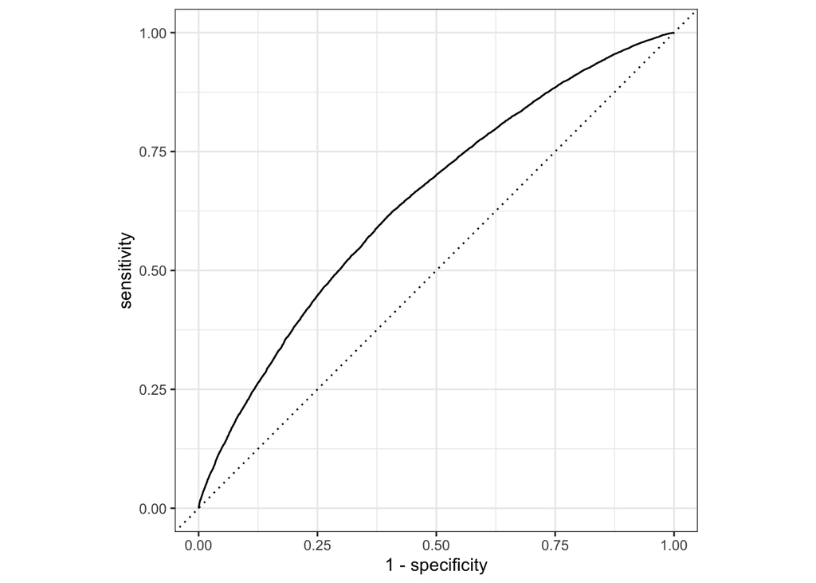

```r
roc_curve(predictions_rf, truth = los_long,
          .pred_TRUE, event_level = "second") %>%
  autoplot()
```

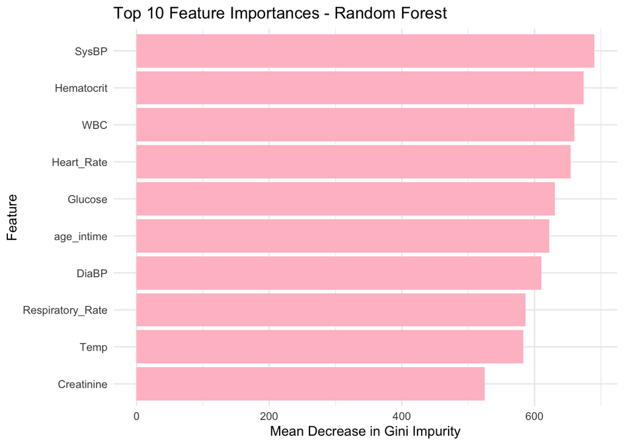

```r
importance_df %>%
  top_n(10, wt = importance) %>%
  ggplot(aes(x = reorder(feature, importance), y = importance)) +
  geom_col(fill = "pink") +
  coord_flip() +
  labs(
    title = "Top 10 Feature Importances - Random Forest",
    x = "Feature",
    y = "Mean Decrease in Gini Impurity"
  ) +
  theme_minimal()
```

**Based on all the results, the accuracy of the RF model is 0.606, while the ROC AUC is 0.6459. This means that the model correctly predicted whether or not a patient was going to stay at longer than or equal to two days about 60% of the time. The ROC AUC illustrates that the model is somewhat effective at distinguishing between long and short stays, but is not the most effective at doing so. Considering that the Logit Regression’s ROC AUC and Accuracy was 0.61 and 0.58, respectively, the Random Forest model is better at predicting long ICU stays.**

**Looking at the importance of variables, SysBP, Hematocrit, WBC, Heart_Rate, and glucose were the most important features in determining whether or not the los_long was greater than or equal to two days. SysBP makes sense considering that this could indicate cardiovascular problems, while Hematocrit may indicate anemia from lack of red blood cells needed for oxygen transportation and survival. However, as we saw with the logistic regression, the SysBP was indicative of a lower LOS, so the importance makes sense as well as it would influence the model results. WBC counts could also indicate infection if there is an elevated amount as well, which would make an individual stay longer. Lastly, Glucose is an indicator of length of stay >= 2 as well. This could be indicative of organs like the pancreas working less so more glucose is building up in the blood stream, causing stress induced hyperglycemia. See below for a more specific reasoning as well**

## XGBoost

**Data Pre-Processing and engineering**

```r
#Remove ID Columns and then Select the Predictors
icu_data <- mimic_icu_cohort %>%
  select(subject_id, hadm_id, stay_id, los_long, first_careunit, gender,
         age_intime, marital_status, race, Heart_Rate, DiaBP, SysBP,
         Respiratory_Rate, Temp, Creatinine, Potassium, Chloride, Bicarbonate,
         Hematocrit, WBC, Sodium, Glucose)

icu_data <- icu_data %>%
  arrange(subject_id, hadm_id, stay_id)


##We need to make sure that los_long is a factor as we got this as an error
icu_data$los_long <- as.factor(icu_data$los_long)

levels(icu_data$los_long)
```

```
[1] "FALSE" "TRUE"
```

```r
##Now we need to remove all the NA values
icu_data <- icu_data %>%
  drop_na(first_careunit, gender, age_intime, marital_status, race, Heart_Rate,
          DiaBP, SysBP, Respiratory_Rate, Temp, Creatinine, Potassium,
          Chloride, Bicarbonate, Hematocrit, WBC, Sodium, Glucose)

##We can check to see if there are any NAs here
colSums(is.na(icu_data))
```

```
      subject_id          hadm_id          stay_id         los_long
               0                0                0                0
  first_careunit           gender       age_intime   marital_status
               0                0                0                0
            race       Heart_Rate            DiaBP            SysBP
               0                0                0                0
Respiratory_Rate             Temp       Creatinine        Potassium
               0                0                0                0
        Chloride      Bicarbonate       Hematocrit              WBC
               0                0                0                0
          Sodium          Glucose
               0                0
```

**Partition data into 50% training set and 50% test set. Stratify partitioning according to los_long. For grading purpose, sort the data by subject_id, hadm_id, and stay_id and use the seed 203 for the initial data split.**

```r
set.seed(203)

icu_split <- initial_split(
  icu_data,
  strata = los_long,
  prop = 0.5
)

icu_train <- training(icu_split)
icu_test <- testing(icu_split)

head(icu_train)
```

```
# A tibble: 6 × 22
  subject_id  hadm_id  stay_id los_long first_careunit         gender age_intime
       <int>    <int>    <int> <fct>    <chr>                  <chr>       <int>
1   10000980 26913865 39765666 FALSE    Medical Intensive Car… F              76
2   10002155 20345487 32358465 FALSE    Medical Intensive Car… F              83
3   10003019 22774359 30676350 FALSE    Medical/Surgical Inte… M              73
4   10003502 29011269 35796366 FALSE    Coronary Care Unit (C… F              94
5   10004457 23251352 31494479 FALSE    Cardiac Vascular Inte… M              66
6   10005348 25239799 34629895 FALSE    Cardiac Vascular Inte… M              78
# ℹ 15 more variables: marital_status <chr>, race <chr>, Heart_Rate <dbl>,
#   DiaBP <dbl>, SysBP <dbl>, Respiratory_Rate <dbl>, Temp <dbl>,
#   Creatinine <dbl>, Potassium <dbl>, Chloride <dbl>, Bicarbonate <dbl>,
#   Hematocrit <dbl>, WBC <dbl>, Sodium <dbl>, Glucose <dbl>
```

```r
head(icu_test)
```

```
# A tibble: 6 × 22
  subject_id  hadm_id  stay_id los_long first_careunit         gender age_intime
       <int>    <int>    <int> <fct>    <chr>                  <chr>       <int>
1   10000032 29079034 39553978 FALSE    Medical Intensive Car… F              52
2   10001217 24597018 37067082 FALSE    Surgical Intensive Ca… F              55
3   10001217 27703517 34592300 FALSE    Surgical Intensive Ca… F              55
4   10001843 26133978 39698942 FALSE    Medical/Surgical Inte… M              76
5   10001884 26184834 37510196 TRUE     Medical Intensive Car… F              77
6   10002013 23581541 39060235 FALSE    Cardiac Vascular Inte… F              57
# ℹ 15 more variables: marital_status <chr>, race <chr>, Heart_Rate <dbl>,
#   DiaBP <dbl>, SysBP <dbl>, Respiratory_Rate <dbl>, Temp <dbl>,
#   Creatinine <dbl>, Potassium <dbl>, Chloride <dbl>, Bicarbonate <dbl>,
#   Hematocrit <dbl>, WBC <dbl>, Sodium <dbl>, Glucose <dbl>
```

**Train and Tune the Models Using the Training Set**

```r
XGBoostRecipe <- recipe(
  los_long ~ first_careunit + gender + age_intime + marital_status + race +
    Heart_Rate + DiaBP + SysBP + Respiratory_Rate + Temp +
    Creatinine + Potassium + Chloride + Bicarbonate + Hematocrit +
    WBC + Sodium + Glucose,
  data = icu_train
) %>%
  step_impute_mean(all_numeric_predictors()) %>%
  step_impute_mode(all_nominal_predictors()) %>%
  step_novel(all_nominal_predictors()) %>%
  step_dummy(all_nominal_predictors()) %>%
  step_zv(all_predictors())
```

**Model specificaiton process with tuning paramters**

```r
xgb_mod <- boost_tree(
  mode = "classification",
  trees = tune(),
  tree_depth = tune(),
  learn_rate = tune()) %>%
  set_engine("xgboost") %>%
  set_mode("classification")

xgb_mod
```

```
Boosted Tree Model Specification (classification)

Main Arguments:
  trees = tune()
  tree_depth = tune()
  learn_rate = tune()

Computational engine: xgboost
```

**Now let us bundle the recipe we did wih our model into a workflow**

```r
xgb_wf <- workflow() |>
  add_recipe(XGBoostRecipe) |>
  add_model(xgb_mod)

xgb_wf
```

```
══ Workflow ════════════════════════════════════════════════════════════════════
Preprocessor: Recipe
Model: boost_tree()

── Preprocessor ────────────────────────────────────────────────────────────────
5 Recipe Steps

• step_impute_mean()
• step_impute_mode()
• step_novel()
• step_dummy()
• step_zv()

── Model ───────────────────────────────────────────────────────────────────────
Boosted Tree Model Specification (classification)

Main Arguments:
  trees = tune()
  tree_depth = tune()
  learn_rate = tune()

Computational engine: xgboost
```

**Now we will define the grid for tuning**

```r
#We received a similar error as before, so use hardhat to remove it

xgb_params <- hardhat::extract_parameter_set_dials(xgb_mod)

xgb_grid <- grid_regular(
  trees(range = c(100L, 500L)),
  tree_depth(range = c(1L, 3L)),
  learn_rate(range = c(-5, 2), trans = log10_trans()),
  levels = c(3, 3, 5)
  )
```

**Now we will perform the tuning**

```r
set.seed(203)

#Kept it consistent; v = 3 was also approved by Dr. Zhou in office hours to speed up my rendering and loading
xgbcv_folds <- vfold_cv(icu_train, v = 3)

xgb_tune <- tune_grid(
  object = xgb_wf,
  resamples = xgbcv_folds,
  grid = xgb_grid,
  metrics = metric_set(roc_auc, accuracy),
  control = control_stack_grid()
)
```

```
ℹ The workflow being saved contains a recipe, which is 5.23 Mb in ℹ memory. If
this was not intentional, please set the control setting ℹ `save_workflow =
FALSE`.
```

```r
best_xgb <- xgb_tune |>
  select_best(metric = "roc_auc")
```

```r
final_xgb_wf <- xgb_wf |>
  finalize_workflow(best_xgb)

final_xgb_fit <- final_xgb_wf |>
  last_fit(icu_split)

final_xgb_fit |>
  collect_metrics()
```

```
# A tibble: 3 × 4
  .metric     .estimator .estimate .config
  <chr>       <chr>          <dbl> <chr>
1 accuracy    binary         0.601 Preprocessor1_Model1
2 roc_auc     binary         0.641 Preprocessor1_Model1
3 brier_class binary         0.234 Preprocessor1_Model1
```

```r
predictions_xgb <- collect_predictions(final_xgb_fit)
conf_mat(predictions_xgb, truth = los_long, estimate = .pred_class)
```

```
          Truth
Prediction FALSE  TRUE
     FALSE 12929  8654
     TRUE   6334  9654
```

```r
final_modelxgb <- extract_fit_parsnip(final_xgb_fit$.workflow[[1]])

importance_df_xgb <- xgb.importance(model = final_modelxgb$fit) %>%
  as_tibble() %>%
  arrange(desc(Gain))

# Show all features and their importance (by Gain)
print(importance_df_xgb, n = Inf)
```

```
# A tibble: 37 × 4
   Feature                                                Gain   Cover Frequency
   <chr>                                                 <dbl>   <dbl>     <dbl>
 1 SysBP                                               9.90e-2 5.13e-2  0.0568
 2 age_intime                                          9.70e-2 6.72e-2  0.0843
 3 first_careunit_Neuro.Intermediate                   8.53e-2 4.42e-2  0.0352
 4 Respiratory_Rate                                    7.90e-2 6.87e-2  0.0606
 5 Creatinine                                          7.76e-2 8.60e-2  0.0710
 6 Heart_Rate                                          7.29e-2 6.43e-2  0.0781
 7 Hematocrit                                          7.06e-2 8.03e-2  0.0781
 8 WBC                                                 5.65e-2 4.56e-2  0.0473
 9 Temp                                                5.39e-2 6.60e-2  0.0568
10 first_careunit_Medical.Surgical.Intensive.Care.Uni… 4.96e-2 5.63e-2  0.0328
11 Bicarbonate                                         4.17e-2 4.73e-2  0.0470
12 Glucose                                             4.08e-2 3.55e-2  0.0689
```

[output cut: 25 more lines]

**Let us plot it in GGPlot for better visualization**

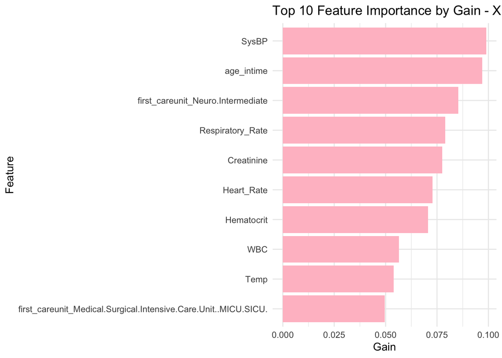

```r
importance_df_xgb %>%
  top_n(10, wt = Gain) %>%
  ggplot(aes(x = reorder(Feature, Gain), y = Gain)) +
  geom_col(fill = "pink") +
  coord_flip() +
  labs(
    title = "Top 10 Feature Importance by Gain - XGBoost",
    x = "Feature",
    y = "Gain"
  ) +
  theme_minimal()
```

**The accuracy and ROC_AUC for the XGBoost model is 0.601 and 0.641, respectively. This indicates that the random_forest was better able to predict los_long >= 2 days, but the XGBoost was better than predicting this than the logit regression.**

**This outcome is quiet interesting, as I expected the XGBoost model to perform better than the random forest model. However, considering that learn_rate is on the lower end, it is not surprising; this means that the XGBoost needed more values to be able to learn the model correctly. The low value that I gave it was not enough, but necessary (and allowed by Dr. Zhou) due to the slow nature of the processing (>= 2ish hours). Given a stronger computer, I would have made this value higher to see if this was the same or better than the random forest model**

**Looking into the gain, cover, and frequency meanings, it looks like SysBP had the highest importance to the model, followed by age_intime and then first_careunit_Neuro.Intermediate.**

**Interestingly, SysBP, age_intime, Respiratory_Rate, first_careunit being the intermediate Neuro one, and Creatinine, were the most important features in determining whether or not the los_long was greater than or equal to two days. This is interesting as the XGBoost model was able to pick up on one of same features as the random forest model (SysBP). This could be due to the fact that the XGBoost model is more sensitive to the features and is able to pick up on the nuances of the data better than the random forest model. However as I stated before, this could also be because of the varying learn_rate, so there is error as well.**

**Comparing XGBoost with Random Forest, both had the SysBP as the highest feature for prediction. They did not share anything else otherwise. Comparing XGBoost to the Logistic Regression Model, however, the similarities included: neuro.intermediate as the first careunit, age_intime, and respiratory_rate, and technically SysBP as well. In other words, it looks like SysBP was a major component across all three models.**

## Model Stacking Log. Regression, Random Forest, and XGBoost

**Data Preprocessing and engineering**

```r
set.seed(203)

# Stratified split by los_long
icu_split <- initial_split(
  icu_data,
  strata = los_long,
  prop = 0.5
)

icu_train <- training(icu_split)
icu_test <- testing(icu_split)

head(icu_train)
```

```
# A tibble: 6 × 22
  subject_id  hadm_id  stay_id los_long first_careunit         gender age_intime
       <int>    <int>    <int> <fct>    <chr>                  <chr>       <int>
1   10000980 26913865 39765666 FALSE    Medical Intensive Car… F              76
2   10002155 20345487 32358465 FALSE    Medical Intensive Car… F              83
3   10003019 22774359 30676350 FALSE    Medical/Surgical Inte… M              73
4   10003502 29011269 35796366 FALSE    Coronary Care Unit (C… F              94
5   10004457 23251352 31494479 FALSE    Cardiac Vascular Inte… M              66
6   10005348 25239799 34629895 FALSE    Cardiac Vascular Inte… M              78
# ℹ 15 more variables: marital_status <chr>, race <chr>, Heart_Rate <dbl>,
#   DiaBP <dbl>, SysBP <dbl>, Respiratory_Rate <dbl>, Temp <dbl>,
#   Creatinine <dbl>, Potassium <dbl>, Chloride <dbl>, Bicarbonate <dbl>,
#   Hematocrit <dbl>, WBC <dbl>, Sodium <dbl>, Glucose <dbl>
```

```r
head(icu_test)
```

```
# A tibble: 6 × 22
  subject_id  hadm_id  stay_id los_long first_careunit         gender age_intime
       <int>    <int>    <int> <fct>    <chr>                  <chr>       <int>
1   10000032 29079034 39553978 FALSE    Medical Intensive Car… F              52
2   10001217 24597018 37067082 FALSE    Surgical Intensive Ca… F              55
3   10001217 27703517 34592300 FALSE    Surgical Intensive Ca… F              55
4   10001843 26133978 39698942 FALSE    Medical/Surgical Inte… M              76
5   10001884 26184834 37510196 TRUE     Medical Intensive Car… F              77
6   10002013 23581541 39060235 FALSE    Cardiac Vascular Inte… F              57
# ℹ 15 more variables: marital_status <chr>, race <chr>, Heart_Rate <dbl>,
#   DiaBP <dbl>, SysBP <dbl>, Respiratory_Rate <dbl>, Temp <dbl>,
#   Creatinine <dbl>, Potassium <dbl>, Chloride <dbl>, Bicarbonate <dbl>,
#   Hematocrit <dbl>, WBC <dbl>, Sodium <dbl>, Glucose <dbl>
```

```r
##Now, let us make the logit_recipe for the logistic regression model

modelstacking <- recipe(
  los_long ~ first_careunit + gender + age_intime + marital_status + race +
    Heart_Rate + DiaBP + SysBP + Respiratory_Rate + Temp +
    Creatinine + Potassium + Chloride + Bicarbonate + Hematocrit +
    WBC + Sodium + Glucose,
  data = icu_train
) %>%
  step_impute_median(all_numeric_predictors()) %>%
  step_impute_mode(all_nominal_predictors()) %>%
  step_novel(all_nominal_predictors()) %>%
  step_dummy(all_nominal_predictors()) %>%
  step_zv(all_predictors()) %>%
  step_normalize(all_numeric_predictors())
```

```r
set.seed(203)
foldsSTACK <- vfold_cv(icu_train, v = 3)
```

## Final Model Stacking:

```r
#The penalty was decided in office hours with Dr. Zhou to speed up the loading process of my modeling.

icu_stack <-
  stacks() %>%
  add_candidates(logit_tune) %>%
  add_candidates(rf_tune) %>%
  add_candidates(xgb_tune) %>%
  blend_predictions(
    penalty = 10^(-6:2),
    metrics = c("roc_auc", "accuracy")
  ) |>
  fit_members()
icu_stack
```

```
── A stacked ensemble model ─────────────────────────────────────


Out of 202 possible candidate members, the ensemble retained 9.

Penalty: 0.01.

Mixture: 1.


The 9 highest weighted member classes are:
```

```
# A tibble: 9 × 3
  member                   type         weight
  <chr>                    <chr>         <dbl>
1 .pred_TRUE_xgb_tune_1_39 boost_tree  1.20
2 .pred_TRUE_rf_tune_1_24  rand_forest 1.05
3 .pred_TRUE_rf_tune_1_25  rand_forest 0.998
4 .pred_TRUE_rf_tune_1_23  rand_forest 0.771
5 .pred_TRUE_rf_tune_1_18  rand_forest 0.698
6 .pred_TRUE_rf_tune_1_19  rand_forest 0.531
7 .pred_TRUE_rf_tune_1_20  rand_forest 0.136
8 .pred_TRUE_rf_tune_1_21  rand_forest 0.102
9 .pred_TRUE_rf_tune_1_16  rand_forest 0.00623
```

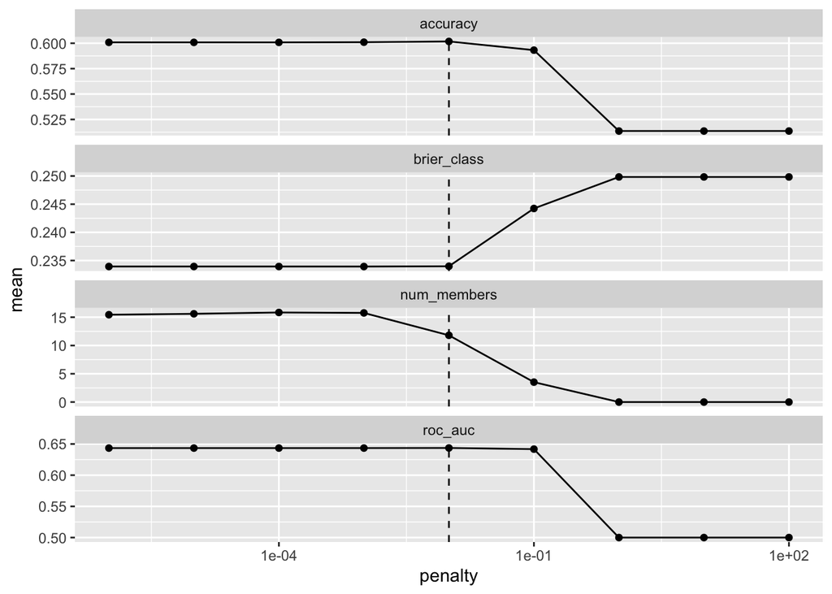

```r
autoplot(icu_stack)
```

**Looking at this picture, the accuracy of 0.6 occurred at the lowest penalty of where the dotted line is at; as the penalty increased, the accuracy decreased as well. The brier_class increased while the penalty increased as well, which is not what we want since a lower brier_class is better. The ROC_AUC was the highest at the location of the dotted line (1e-02 probably) and then was moderately the same until about 1e-01, but then decreased to 0.50 as the penalties increased. With all of this in mind, it is suggested that in the future that a penalty of 1e-02 is used for better results and performance**

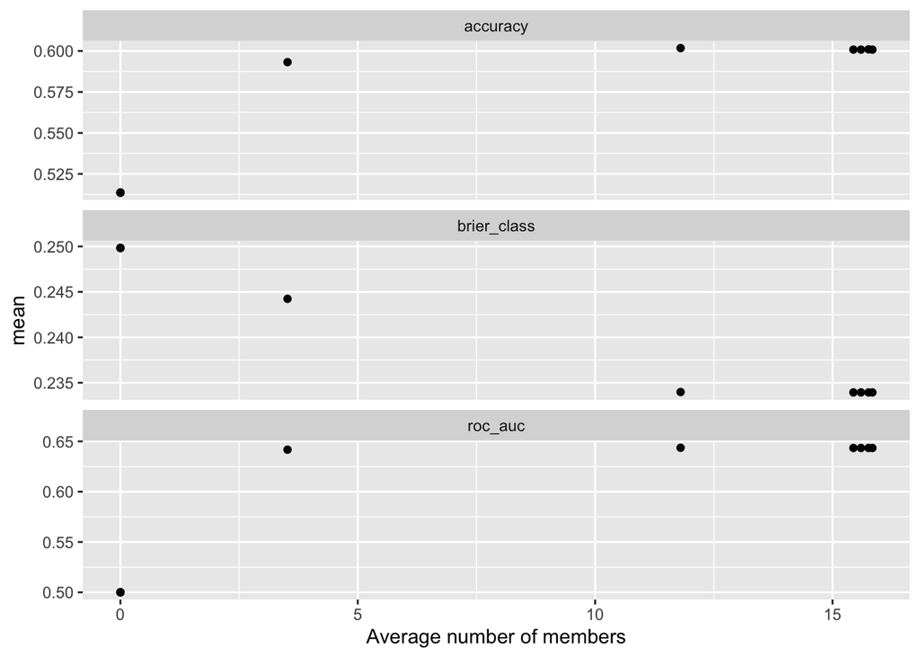

```r
autoplot(icu_stack, type = "members")
```

**this makes sense, higher number of members would create higher accuracy, which is seen, better calibration, which is seen by the brier_class, and higher ROC AUC. In essence, higher average number of members created better performance of the model.**

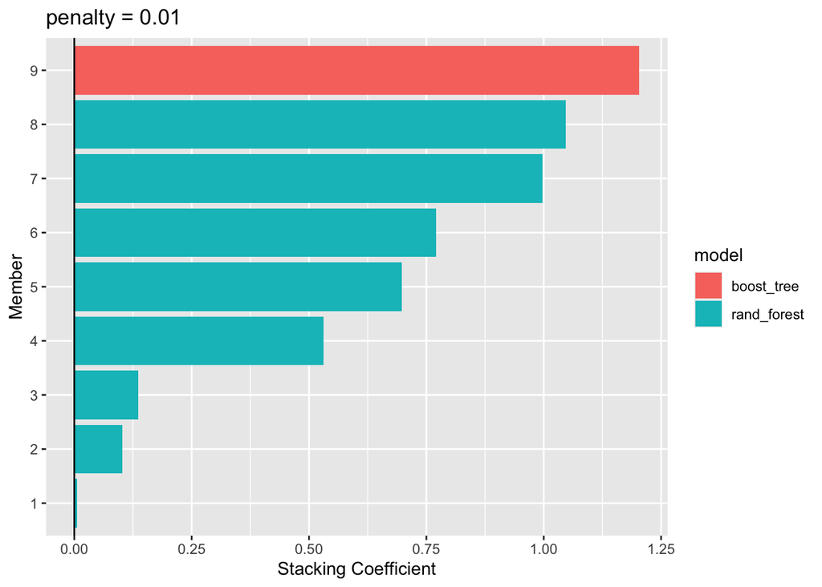

```r
autoplot(icu_stack, type = "weights")
```

**This graph illustrates that boost_tree had the highest weight in the model and that the stacked model had a better time utilizing random forest compared to random forest or Log. Reg.. Surprisingly, Log. Reg is not on there at all. However, considering that XGBoost and RF had better accuracy and ROC_AUC compared to Log. Reg., this is believable.**

```r
collect_parameters(icu_stack, "rf_tune") |>
  arrange(desc(coef)) |>
  print(n = Inf)
```

```
# A tibble: 25 × 5
   member        mtry trees terms                      coef
   <chr>        <int> <int> <chr>                     <dbl>
 1 rf_tune_1_24     5   400 .pred_TRUE_rf_tune_1_24 1.05
 2 rf_tune_1_25     5   500 .pred_TRUE_rf_tune_1_25 0.998
 3 rf_tune_1_23     5   300 .pred_TRUE_rf_tune_1_23 0.771
 4 rf_tune_1_18     4   300 .pred_TRUE_rf_tune_1_18 0.698
 5 rf_tune_1_19     4   400 .pred_TRUE_rf_tune_1_19 0.531
 6 rf_tune_1_20     4   500 .pred_TRUE_rf_tune_1_20 0.136
 7 rf_tune_1_21     5   100 .pred_TRUE_rf_tune_1_21 0.102
 8 rf_tune_1_16     4   100 .pred_TRUE_rf_tune_1_16 0.00623
 9 rf_tune_1_01     1   100 .pred_TRUE_rf_tune_1_01 0
10 rf_tune_1_02     1   200 .pred_TRUE_rf_tune_1_02 0
11 rf_tune_1_03     1   300 .pred_TRUE_rf_tune_1_03 0
12 rf_tune_1_04     1   400 .pred_TRUE_rf_tune_1_04 0
13 rf_tune_1_05     1   500 .pred_TRUE_rf_tune_1_05 0
14 rf_tune_1_06     2   100 .pred_TRUE_rf_tune_1_06 0
15 rf_tune_1_07     2   200 .pred_TRUE_rf_tune_1_07 0
16 rf_tune_1_08     2   300 .pred_TRUE_rf_tune_1_08 0
17 rf_tune_1_09     2   400 .pred_TRUE_rf_tune_1_09 0
18 rf_tune_1_10     2   500 .pred_TRUE_rf_tune_1_10 0
19 rf_tune_1_11     3   100 .pred_TRUE_rf_tune_1_11 0
20 rf_tune_1_12     3   200 .pred_TRUE_rf_tune_1_12 0
21 rf_tune_1_13     3   300 .pred_TRUE_rf_tune_1_13 0
22 rf_tune_1_14     3   400 .pred_TRUE_rf_tune_1_14 0
23 rf_tune_1_15     3   500 .pred_TRUE_rf_tune_1_15 0
24 rf_tune_1_17     4   200 .pred_TRUE_rf_tune_1_17 0
25 rf_tune_1_22     5   200 .pred_TRUE_rf_tune_1_22 0
```

**The most important members from the random_forest are showed above. Specifically, the first three had the highest coef. indicating a higher weight/influence on the final stacked model prediction. It looks like when the mtry was 5 and the trees were 400, the coefficient was highest (1.05)**

```r
collect_parameters(icu_stack, "logit_tune") |>
  arrange(desc(coef)) |>
  print(n = Inf)
```

```
# A tibble: 138 × 5
    member             penalty mixture terms                        coef
    <chr>                <dbl>   <dbl> <chr>                       <dbl>
  1 logit_tune_1_001  0.000001    0    .pred_TRUE_logit_tune_1_001     0
  2 logit_tune_1_042  0.00534     0    .pred_TRUE_logit_tune_1_042     0
  3 logit_tune_1_043  0.00658     0    .pred_TRUE_logit_tune_1_043     0
  4 logit_tune_1_044  0.00811     0    .pred_TRUE_logit_tune_1_044     0
  5 logit_tune_1_045  0.01        0    .pred_TRUE_logit_tune_1_045     0
  6 logit_tune_1_046  0.0123      0    .pred_TRUE_logit_tune_1_046     0
  7 logit_tune_1_047  0.0152      0    .pred_TRUE_logit_tune_1_047     0
  8 logit_tune_1_048  0.0187      0    .pred_TRUE_logit_tune_1_048     0
  9 logit_tune_1_049  0.0231      0    .pred_TRUE_logit_tune_1_049     0
 10 logit_tune_1_050  0.0285      0    .pred_TRUE_logit_tune_1_050     0
 11 logit_tune_1_051  0.0351      0    .pred_TRUE_logit_tune_1_051     0
 12 logit_tune_1_052  0.0433      0    .pred_TRUE_logit_tune_1_052     0
```

[output cut: 126 more lines]

**This shows that the logit_tune contributed not much to the model or anything since all the coefficients were zero.**

```r
collect_parameters(icu_stack, "xgb_tune") |>
  arrange(desc(coef)) |>
  print(n = Inf)
```

```
# A tibble: 39 × 6
   member        trees tree_depth learn_rate terms                     coef
   <chr>         <int>      <int>      <dbl> <chr>                    <dbl>
 1 xgb_tune_1_39   500          3   0.0316   .pred_TRUE_xgb_tune_1_39  1.20
 2 xgb_tune_1_01   100          1   0.00001  .pred_TRUE_xgb_tune_1_01  0
 3 xgb_tune_1_02   300          1   0.00001  .pred_TRUE_xgb_tune_1_02  0
 4 xgb_tune_1_03   500          1   0.00001  .pred_TRUE_xgb_tune_1_03  0
 5 xgb_tune_1_04   100          1   0.000562 .pred_TRUE_xgb_tune_1_04  0
 6 xgb_tune_1_05   300          1   0.000562 .pred_TRUE_xgb_tune_1_05  0
 7 xgb_tune_1_06   500          1   0.000562 .pred_TRUE_xgb_tune_1_06  0
 8 xgb_tune_1_07   100          1   0.0316   .pred_TRUE_xgb_tune_1_07  0
 9 xgb_tune_1_08   300          1   0.0316   .pred_TRUE_xgb_tune_1_08  0
10 xgb_tune_1_09   500          1   0.0316   .pred_TRUE_xgb_tune_1_09  0
11 xgb_tune_1_10   100          1   1.78     .pred_TRUE_xgb_tune_1_10  0
12 xgb_tune_1_11   300          1   1.78     .pred_TRUE_xgb_tune_1_11  0
```

[output cut: 27 more lines]

**XGB_tune contributed once to the stacked model, more than the Log. Reg., but less than the random_forest. The hihghest coefficient was seen at tree 500 with a tree_depth of 3. The coefficient was 1.204**

```r
icu_stack_pred <- icu_test %>%
  bind_cols(predict(icu_stack, ., type = "prob")) %>%
  print(width = Inf)
```

```
# A tibble: 37,571 × 24
   subject_id  hadm_id  stay_id los_long
        <int>    <int>    <int> <fct>
 1   10000032 29079034 39553978 FALSE
 2   10001217 24597018 37067082 FALSE
 3   10001217 27703517 34592300 FALSE
 4   10001843 26133978 39698942 FALSE
 5   10001884 26184834 37510196 TRUE
 6   10002013 23581541 39060235 FALSE
 7   10002428 23473524 35479615 TRUE
 8   10002428 28662225 38875437 TRUE
 9   10002443 21329021 35044219 TRUE
10   10002930 25696644 37049133 FALSE
   first_careunit                                   gender age_intime
   <chr>                                            <chr>       <int>
```

[output cut: 47 more lines]

**This illustrates with the given values, the probability that the patient would have a stay longer than or equal to two days**

```r
yardstick::roc_auc(
  icu_stack_pred,
  truth = los_long,
  .pred_TRUE,
  event_level = "second"
)
```

```
# A tibble: 1 × 3
  .metric .estimator .estimate
  <chr>   <chr>          <dbl>
1 roc_auc binary         0.648
```

**This ROC_AUC of the stacked model is 0.647. This means that this is better than random guessing (which would be 50%). This is also the best models**

```r
icu_pred <-
  icu_test |>
  select(los_long) |>
  bind_cols(
    predict(
      icu_stack,
      icu_test,
      type = "class",
      members = TRUE
    )
  ) |>
  print(width = Inf)
```

```
# A tibble: 37,571 × 11
   los_long .pred_class .pred_class_rf_tune_1_16 .pred_class_rf_tune_1_18
   <fct>    <fct>       <fct>                    <fct>
 1 FALSE    TRUE        TRUE                     TRUE
 2 FALSE    TRUE        TRUE                     FALSE
 3 FALSE    FALSE       FALSE                    FALSE
 4 FALSE    FALSE       FALSE                    FALSE
 5 TRUE     FALSE       FALSE                    FALSE
 6 FALSE    FALSE       FALSE                    FALSE
 7 TRUE     TRUE        TRUE                     TRUE
 8 TRUE     FALSE       FALSE                    TRUE
 9 TRUE     FALSE       FALSE                    FALSE
10 FALSE    FALSE       TRUE                     FALSE
   .pred_class_rf_tune_1_19 .pred_class_rf_tune_1_20 .pred_class_rf_tune_1_21
   <fct>                    <fct>                    <fct>
```

[output cut: 35 more lines]

```r
icu_pred_accuracy <-
  map(
    colnames(icu_pred)[-1],
    ~mean(icu_pred$los_long == pull(icu_pred, .x))
  ) |>
  set_names(colnames(icu_pred)[-1]) |>
  as_tibble() |>
  pivot_longer(cols = everything(), names_to = "model", values_to = "accuracy")

icu_pred_accuracy
```

```
# A tibble: 10 × 2
   model                     accuracy
   <chr>                        <dbl>
 1 .pred_class                  0.606
 2 .pred_class_rf_tune_1_16     0.600
 3 .pred_class_rf_tune_1_18     0.605
 4 .pred_class_rf_tune_1_19     0.605
 5 .pred_class_rf_tune_1_20     0.604
 6 .pred_class_rf_tune_1_21     0.598
 7 .pred_class_rf_tune_1_23     0.605
 8 .pred_class_rf_tune_1_24     0.606
 9 .pred_class_rf_tune_1_25     0.606
10 .pred_class_xgb_tune_1_39    0.601
```

**Looking at the .pred_class, the accuracy of the model is 0.6064. This is better than the accuracy of the RF model and the XGBoost model. However, this model is better than the RF model accuracy wise by 0.0001. This would also make it better than the logistic regression model as well.**

**Specifically focusing on performance, I would say that the RF model had the best performance out of the three. This is because it gave back a high ROC AUC and accuracy (close to that of the stacked model) while also taking a reasonable amount of time to load. Although the logistic regression was fast, it was not that accurate. The XGBoost was significantly slower and yield worse results than the RF Model. My recommendation would be to use the random_forest if time permits, especially considering that the accuracy was only worse than the stacked model by 0.0001.**

**For the question: What are the most important features in predicting long ICU stays? Please see the other establishments from above. For example, I would say that one of the most important factors would include SysBP, however, there are others as well as mentioned before. Although none of them had very much common ones all around, it looks like SysBP, age_intime, heart_rate, WBC, Hematocrit, and Respiratory_Rate, were some of the most important features in determining whether or not the los_long was greater than or equal to two days.**

**I think out of the four models, the logistic regression was the easiest one to interpret as you could just look at the estimates and see which one had the highest one and impacted the model the most. The random forest and XGBoost models were harder to interpret as they had features that impacted the model in different ways. The stacked model was also hard to interpret as it was a combination of the three models, so it was hard to see which model had the most impact on the final prediction, and it was very time consuming as well. I stick by my suggestion for random forest as it seems to have the best balance of performance and interpretability as a result. However, interpretability is based on the individual’s understanding on the models themselves. I think that a logistic regression is so commonly known about, it makes it easier to understand what it is stating. I think with more information and dissection of the components of all the models, that it could easily be up to the individual to decide which one is the most interpretable. To me, however, I think the logistic regression is the easiest to understand given all the information, but if its based on accuracy and predictability, then the stacked model would win because it had the highest out of the four. Out of convenience and efficacy, the random forest would win. In other words, it is up to the goal of the individual to figure out which one works best depending on the situation being examined/questioned**